# Advanced Graphs

Barry DeCicco

2025-09-11

## Contents

This presentation covers various useful plot tips I’ve picked up from various sources. It’s intended to make your life a bit simpler. My sources are the R Graph Gallery, LinkedIn posts and the Medium website.

## R Graph Gallery

This is a great resource (https://r-graph-gallery.com) which contains illustrations and code chunks for a large variety of plots, and variations within plot types. It is the first place to check.

## The SanKey Diagram

The SanKey diagram is used to illustrate the low of quantities from earlier sources to later (or intermediate) destinations.

Sankey diagrams are named after Irish Captain Matthew Henry Phineas Riall Sankey, who used this type of diagram in 1898 in a classic figure showing the energy efficiency of a steam engine. The original charts in black and white displayed just one type of flow (e.g. steam); using colors for different types of flows lets the diagram express additional variables. (See: https://en.wikipedia.org/wiki/Sankey_diagram#cite_note-3)

You will need the package ‘networkD3’.

Data sources:

- Connection data frame, which has three lists - sources, destinations and values
- Incidence matrix, which is a square matrix, which must be converted into a connection data frame first.

```r
# from:  https://r-graph-gallery.com/sankey-diagram.html

# Library - must have the pagkage networkD3
library(networkD3)
library(dplyr)
# A connection data frame is a list of flows with intensity for each flow
links <- data.frame(
  source=c("group_A","group_A", "group_B", "group_C", "group_C", "group_E"),
  target=c("group_C","group_D", "group_E", "group_F", "group_G", "group_H"),
  value=c(2,3, 2, 3, 1, 3)
  )

# From these flows we need to create a node data frame: it lists every entities involved in the flow
nodes <- data.frame(
  name=c(as.character(links$source),
  as.character(links$target)) %>% unique()
)

# With networkD3, connection must be provided using id, not using real name like in the links dataframe.. So we need to reformat it.
links$IDsource <- match(links$source, nodes$name)-1
links$IDtarget <- match(links$target, nodes$name)-1

# Make the Network
p <- sankeyNetwork(Links = links, Nodes = nodes,
              Source = "IDsource", Target = "IDtarget",
              Value = "value", NodeID = "name",
              sinksRight=FALSE)
p
```

[interactive chart not shown]

```r
# save the widget
# library(htmlwidgets)
# saveWidget(p, file=paste0( getwd(), "/HtmlWidget/sankeyBasic1.html"))
```

### Variations

There are two variations: - A bump chart, to illustrate changes in ranks rather than values. - An Alluvial chart, which is used for freqcencies rather than values.

### Bump Plot with highlighting.

Here’s an example from the R Graph Gallery for a bump chart which highlights ranks.

The dataset is retrieved from the rdbnomics package and is from the AMECO database.

It contains the share of gross fixed capital formation (GFCF) in % of GDP for a selection of European countries. The data is available for the years 2000, 2010 and 2020.

This pre-processing step is necessary to rank the countries according to their share of GFCF in % of GDP. The rank() function is used to create a ranking variable for each year.

The countrycode() function is used to convert the ISO3 country codes to country names in German.

```r
# Library
library(tidyverse)
library(countrycode)
library(rdbnomics)
library(ggbump)
library(MetBrewer)
library(scales)
allcty <- codelist |> filter(!is.na(eu28)) |> pull(iso3c) |> tolower()

gfcf_private <- rdb(provider_code = "AMECO", dataset_code = "UIGP",
             dimensions = list(geo = allcty, unit = "mrd-ecu-eur"))
gdp <- rdb(provider_code = "AMECO", dataset_code = "UVGD",
           dimensions = list(geo = allcty, unit = "mrd-ecu-eur"))

data <- bind_rows(gfcf_private, gdp) |>
  mutate(variable = case_when(
    str_detect(dataset_name, "private") ~ "GFCF_p",
    TRUE ~ "GDP")) |>
  select(geo, variable, period, value) |>
  pivot_wider(names_from = variable, values_from = value) |>
  mutate(share_p = GFCF_p/GDP*100, year = year(period), geo = toupper(geo))

ranked <- data |>
  filter(year %in% c(2000, 2010, 2020)) |>
  mutate(ranking = rank(desc(share_p), ties.method = "first"), .by = year) |>
  mutate(ctry = countrycode(geo, "iso3c", "country.name.de"),
         ctry = ifelse(geo == "CZE", "Tschechien", ctry))

selected <- c("AUT", "DEU", "IRL", "FRA")

head(ranked, n=10)
```

```
## # A tibble: 10 × 8
##    geo   period     GFCF_p   GDP share_p  year ranking ctry
##    <chr> <date>      <dbl> <dbl>   <dbl> <dbl>   <int> <chr>
##  1 AUT   2000-01-01  48.9  212.     23.0  2000       6 Österreich
##  2 AUT   2010-01-01  54.6  294.     18.6  2010       5 Österreich
##  3 AUT   2020-01-01  82.9  380.     21.8  2020       3 Österreich
##  4 BEL   2000-01-01  51.6  256.     20.1  2000      14 Belgien
##  5 BEL   2010-01-01  71.5  363.     19.7  2010       2 Belgien
##  6 BEL   2020-01-01  98.7  464.     21.3  2020       4 Belgien
##  7 BGR   2000-01-01   1.86  14.4    12.8  2000      27 Bulgarien
##  8 BGR   2010-01-01   6.74  38.3    17.6  2010       7 Bulgarien
##  9 BGR   2020-01-01   9.70  61.9    15.7  2020      21 Bulgarien
## 10 CYP   2000-01-01   1.80  10.8    16.6  2000      22 Zypern
```

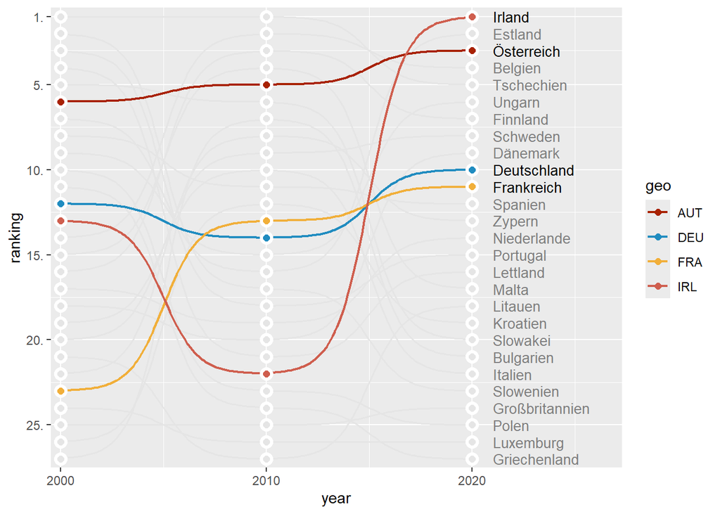

```r
ranked |>
  ggplot(aes(x = year, y = ranking, group = geo)) +
  geom_bump(linewidth = 0.6, color = "gray90", smooth = 6) +
  geom_bump(aes(color = geo), linewidth = 0.8, smooth = 6,
                    data = ~. |> filter(geo %in% selected)) +
  geom_point(color = "white", size = 4) +
  geom_point(color = "gray90", size = 2) +
  geom_point(aes(color = geo), size = 2,
             data = ~. |> filter(geo %in% selected)) +
  geom_text(aes(label = ctry), x = 2021, hjust = 0,
            color = "gray50", family = "Roboto Condensed", size = 3.5,
            data = ranked |> slice_max(year, by = geo) |>
              filter(!geo %in% selected)) +
  geom_text(aes(label = ctry), x = 2021, hjust = 0,
            color = "black", family = "Roboto Condensed", size = 3.5,
            data = ranked |> slice_max(year, by = geo) |>
              filter(geo %in% selected)) +
  scale_color_manual(values = met.brewer("Juarez")) +
  scale_x_continuous(limits = c(1999.8, 2027), expand = c(0.01,0),
                     breaks = c(2000, 2010, 2020)) +
  scale_y_reverse(breaks = c(25,20,15,10,5,1), expand = c(0.02,0),
                  labels = number_format(suffix = "."))
```

## ggstream - another ‘over time’ chart -

This creates what the package author called ‘streamographs’, another way of showing change over time. It requires the package ‘ggstream’.

It has options for producing symmetric plots, stacked plots, and proportional plots (everything adds up to 100%).

#### Basic

```r
# install.packages("ggstream")
library(ggstream)
```

```r
library(ggplot2)

head(blockbusters, n=20)
```

```
## # A tibble: 20 × 3
##     year genre     box_office
##    <dbl> <chr>          <dbl>
##  1  1977 Action         2.98
##  2  1977 Adventure      0.209
##  3  1977 Comedy         0.516
##  4  1977 Drama          2.54
##  5  1978 Action         1.92
##  6  1978 Adventure      0.760
##  7  1978 Comedy         1.04
##  8  1978 Drama          0.202
##  9  1979 Action         1.15
## 10  1979 Adventure      0.312
## 11  1979 Comedy         0.563
## 12  1979 Drama          1.02
## 13  1980 Action         1.80
## 14  1980 Adventure      0.583
## 15  1980 Comedy         1.20
## 16  1981 Action         1.75
## 17  1981 Adventure      0.126
## 18  1981 Comedy         0.688
## 19  1981 Drama          0.355
## 20  1982 Action         0.773
```

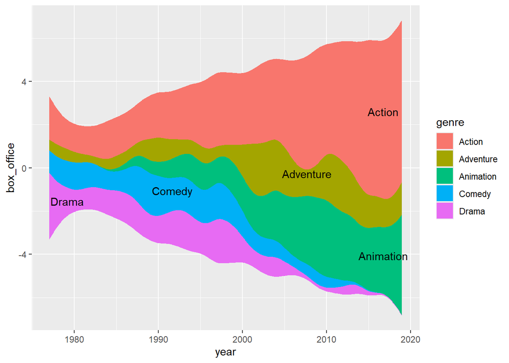

```r
ggplot(blockbusters, aes(year, box_office, fill = genre)) +
  geom_stream() +
  geom_stream_label(aes(label = genre))
```

## Other Links:

- ggside (https://cran.r-project.org/web/packages/ggside/vignettes/ggside_basic_usage.html)- allows the addition of side plots to ggplot graphs.
- ggrepl (https://ggrepel.slowkow.com/) spaces labels to avoid overlap.
- add_test_pvalue (example at add_test_pvalue) - adds stastistical tests and results.
- ggscatterstats/ggstatsplot (https://github.com/IndrajeetPatil/ggstatsplot) - adds marginal plots to plots.
- ggbetweenstats (https://github.com/IndrajeetPatil/ggstatsplot) - displays differences between groups.
- ggalign (https://github.com/Yunuuuu/ggalign) lines up results in tabular form.
- ggridges (https://statisticsglobe.com/ridgeline-plots-in-r) creates ridge plots, showing distribution over categories.

## References:

- The R Graph Gallery (https://r-graph-gallery.com)
  - The SanKey diagram (https://r-graph-gallery.com/sankey-diagram.html)
- R-Charts (r-charts.com)
  - Stream plots in ggplot2 with geom_stream (Stream plots in ggplot2 with geom_stream)
- Wikipedia (https://en.wikipedia.org/wiki/Main_Page)
  - The SanKey diagram (https://en.wikipedia.org/wiki/Sankey_diagram)
- Bump plot with highlighting (https://r-graph-gallery.com/web-bump-plot-with-highlights.html)
- ggstream
  - Github (https://github.com/davidsjoberg/ggstream)
  - LinkedIn post (https://www.linkedin.com/posts/statisticsglobe_tidyverse-visualanalytics-datascience-activity-7368189211981553664-Yv2J/?utm_source=share&utm_medium=member_desktop&rcm=ACoAAAEzU6MB0kVHCNuKg0uQsqI8A-QHPl2UNwQ)